# 04. Transfer Learning with TensorFlow Part 1: Feature Extraction

We've built many CNN models from scratch that all learnt, however this is done through adding more laers, changing learning rate, adjusting every parameters etc.

This is very time consuming, so we use a different method called `transfer learning`. In other words, using a model's learnt patterns (aka. weights) from a problem to then be applied on our own problem. Two main benefits are:

1. Can leverage an existing neural network architevture proven to work on problems similar to our own.
2. Can leverage a working neural network architecture which has already learned patterns on similar data to our own. Achieving greater results with less custom data.

In other terms, we can utilise models that have similar problems to ours, rather than hand-crafting our own neural network architectures and building them from scratch.

Instead of training from scratch, we take the patterns a model has learned from datasets like `ImageNet`, then use them as foundation of our own.

### What we're covering

- Introduce transfer learning (a way to beat all of our old self-built models)
- Using a smaller dataset to experiment faster (10% of training samples of 10 classes of food)
- Build a transfer learning feature extraction model using TensorFlow Hub
- Introduce the TensorBoard callback to track model training results
- Compare model results using TensorBoard

```python
# add timestamp
import datetime
print(f'This notebook was last run (end-to-end): {datetime.datetime.now()}')
```

```
This notebook was last run (end-to-end): 2025-08-29 22:16:35.974447
```

### Using a GPU

To begin, let's check if we're using a GPU, as that'll drastically speed up training compared to CPU

```python
# Are we using a GPU?
!nvidia-smi
```

[output not shown]

### Transfer learning with TensorFlow Hub: Getting great results with 10% of the data

Many problems that you'll require deep learning for, would've most likely been solved with a similar model. And these are often available from TensorFlow Hub, aka Kaggle.

Its a repository for existing model components, making it so you can import and use fully trained models quickly.

Surprisingly, transfer learning is very efficient. Where the model can learn from 10% of the data, and outperform the best model that we can create from scratch.

We will see this in practice by training on 10% of training data from the `10_food_classes` dataset.

[figure not shown]

*Example of what we're building. Taking pre-trained model and adding our custom layer on top. (Top layer is our input layer of our problem. In this case, the 10 food category).*

### Downloading and becoming one with the data

```python
# Get data (10% of total)
import zipfile

# Unzip the downloaded file
zip_ref = zipfile.ZipFile('10_food_classes_10_percent.zip', 'r')
zip_ref.extractall()
zip_ref.close()
```

```python
# How many images in folder?
import os

# Walk through directory, and list the number of files
for dirpath, dirnames, filenames in os.walk('10_food_classes_10_percent'):
    print(f'There are {len(dirnames)} directories and {len(filenames)} images in "{dirpath}"')
```

```
There are 2 directories and 0 images in "10_food_classes_10_percent"
There are 10 directories and 0 images in "10_food_classes_10_percent\test"
There are 0 directories and 250 images in "10_food_classes_10_percent\test\ice_cream"
There are 0 directories and 250 images in "10_food_classes_10_percent\test\chicken_curry"
There are 0 directories and 250 images in "10_food_classes_10_percent\test\steak"
There are 0 directories and 250 images in "10_food_classes_10_percent\test\sushi"
There are 0 directories and 250 images in "10_food_classes_10_percent\test\chicken_wings"
There are 0 directories and 250 images in "10_food_classes_10_percent\test\grilled_salmon"
There are 0 directories and 250 images in "10_food_classes_10_percent\test\hamburger"
There are 0 directories and 250 images in "10_food_classes_10_percent\test\pizza"
There are 0 directories and 250 images in "10_food_classes_10_percent\test\ramen"
There are 0 directories and 250 images in "10_food_classes_10_percent\test\fried_rice"
There are 10 directories and 0 images in "10_food_classes_10_percent\train"
There are 0 directories and 75 images in "10_food_classes_10_percent\train\ice_cream"
There are 0 directories and 75 images in "10_food_classes_10_percent\train\chicken_curry"
There are 0 directories and 75 images in "10_food_classes_10_percent\train\steak"
There are 0 directories and 75 images in "10_food_classes_10_percent\train\sushi"
There are 0 directories and 75 images in "10_food_classes_10_percent\train\chicken_wings"
There are 0 directories and 75 images in "10_food_classes_10_percent\train\grilled_salmon"
There are 0 directories and 75 images in "10_food_classes_10_percent\train\hamburger"
There are 0 directories and 75 images in "10_food_classes_10_percent\train\pizza"
There are 0 directories and 75 images in "10_food_classes_10_percent\train\ramen"
There are 0 directories and 75 images in "10_food_classes_10_percent\train\fried_rice"
```

Training images should've been 750, but is 75. Meaning we got the right version with only 10% of the files. The test directories still have the same amount of images as the 100% full dataset. Meaning we are training on images that are less in numbers than the test images.

### Creating data loaders (preparing the data)

Let's use `ImageDataGenerator` class along with the `flow_from_directory` method to load in our images.

```python
# setup data inputs
import tensorflow as tf
from tensorflow.keras.preprocessing.image import ImageDataGenerator

IMAGE_SHAPE = (224,224)
BATCH_SIZE = 32

train_dir='10_food_classes_10_percent/train/'
test_dir='10_food_classes_10_percent/test/'

datagen=ImageDataGenerator(rescale=1/255.)

print('Training images:')
train_data_10_percent=datagen.flow_from_directory(train_dir,
                                                  target_size=IMAGE_SHAPE,
                                                  batch_size=BATCH_SIZE,
                                                  class_mode='categorical')

print('Testing images:')
test_data=datagen.flow_from_directory(test_dir,
                                                 target_size=IMAGE_SHAPE,
                                                 batch_size=BATCH_SIZE,
                                                 class_mode='categorical')
```

```
Training images:
Found 750 images belonging to 10 classes.
Testing images:
Found 2500 images belonging to 10 classes.
```

```python
!pip install tensorflow-hub
```

[output not shown]

[output cut: 432 more lines]

[output not shown]

[output not shown]

### Setting up callbacks (things to run whilst our model trains)

Callbacks is a very important concept in the future, as we further build more experiments.

Its an extra functionality thats added to your models, where it performs during or after training. A few popular callbacks include:

- `Experiment tracking with TensorBoard` - log the performance of multiple models, then view and compare them visually using `TensorBoard`. Its a dashboard for inspecting neural network parameters. This is helpful in comparing results of different models on your data.
- `Model checkpointing` - save your model in the middle of training, so you can come back to it from where it was last trained. Helpful when training takes forever and can't be reasonably done in one sitting.
- `Early stopping` - leave your model training for an arbitrarily long time, then let it stop early when it detects no improvement. Helpful with large datasets where you don't know how long training will take.

These will be explored eventually, though our first focus will be on TensorBoard callback, and how it can be used.

TensorBoard can be accessed with `tf.keras.callbacks.TensorBoard()`.

It's main function is saving a model's training performance metrics to a specified `log_dir`.

By default, logs are recorded every epoch using the `update_freq='epoch'` parameter. Which is good, as you can record logs by batchs or integer, which is much more frequent, and slows everything down. Epoch gives enough idea on model progress, and also don't slow down by spending lots of time writing logs.

To track our modelling experiments with TensorBoard, we'll create a function which creates a TensorBoard callback for us.

> **Note**: Each model needs their own TensorBoard callback instance. Which is why we will form a function to streamline the process for future models. This is because, they work like logs. if the same log is reused on a different model, it overwrites whatever that was archived in it.

```python
# create tensorboard callback (functionized due to every model needing its own callback)
import datetime
def create_tensorboard_callback(dir_name, experiment_name):
    log_dir = dir_name + "/" + experiment_name + "/" + datetime.datetime.now().strftime('%Y%m%d-%H%M%S')
    tensorboard_callback = tf.keras.callbacks.TensorBoard(
        log_dir=log_dir)

    print(f'Saving TensorBoard log files to: {log_dir}')
    return tensorboard_callback
```

As we're running multiple experiments, its best to track them in some way, so you don't lost track.

Our function saves a model's performance log to directories that are names accordingly: `[dir_name]/[experiment_name]/[current_timestamp]`

- `[dir_name]` - the overall log directory
- `[experiment_name]` - the particular experiment
- `[current_timestamp]` - the time the experiment started, based on when `datetime` code was ran

> **Note**: This can be one way of keeping track of logs, and its naming method. You are able to modify the naming and placing of where the logs are to suit your needs, or your project. Make sure names are understandable to you and your team.

### Creating modles from Kaggle

We've created models layer by layer in the past. We'll still do a similar process, but the majority of the layers will come from Kaggle.

We'll use two models specifically:

- `ResNetV2` - a state of the art computer vision model architecture from 2016
- `EfficientNet` - a state of the art computer vision architecture from 2019

State of the art, meant it achieved the lowest possible error rate on `ImageNet (ILSVRC-2012-CLS)`. The gold standard for computer benchmarking.

The steps in finding the right model for you:

1. Use filters and select the classification type or framework etc. (We're using tensorflow 2, so select that)
2. Search for your problem domain on the search bar if needing more specifics (e.g. videos)
3. Remove all 'problem domain' filters except for problems you are working on
4. Results should be all models that potentially work on any problem you have

> **Question**: There are many models after refining. How do I know which is best?

Usually, try find the model that has the lowest error rate overall on a benchmark problem. For example, we're working with images. So we'll try find models which perform best on ImageNet: https://huggingface.co/papers/trending

5. Once you select a model you like say this [efficient net](https://www.kaggle.com/models/tensorflow/efficientnet/tensorFlow2/b0-feature-vector/1?tfhub-redirect=true) model, go to `Model Variation` and select a model. Good rule of thumb is the higher numbers say `B6` compared to `B0`, means a better model. But it does often translate to longer training time.
6. Click the `b0-feature-vector` and click the download button

> **Question**: Why are we downloading `feature vector`? Shouldn't it be `classification` because we're doing an image classification problem???

This is where different types of transfer learning come into play, as in the feature extraction and fine tuning.

1. **"As is" transfer learning**: Where you take a pretrained model, and apply it 'as is' onto your problem without any changes.
   - An example is most computer vision models are pretrained on `ImageNet`, which contained 1000 different classes. So when passing a single image, it'll produce 1000 prediction probabilities. One for every class it's studied.
     - This helpful if you have 1000 classes, and they happen to be the exact same classes as was used in `ImageNet`. Though is not as useful, if you have 10 classes of food variation.
2. **Feature extraction transfer learning**: Taking the underlying presets (weights) of a pretrained model, and adjust its outputs to suit your problem.
   - A model is pretrained with many layers, but the top layer outputs 1000 different classes. Which doesn't suit your 10 class food problem. To adjust this, you may remove the original activation layer and replace it with your own that has the right number of output classes. Most important takeaway is **the top layer is changed to suit your problem. But everything else underneath is frozen in place**.
     - This way, all underlying patterns and weights remain the same as original. Which is good if your data is not exactly the same as the problem's original data, but similar enough.
3. **Fine-tuning transfer learning**: Taking the layers of the pretrained model, and adjusting the weights to fit your problem even better.
   - This means you train on some, most, or even all of the layers. It's useful for large datasets with many classes, where the classes don't fit in so cleanly with the original classes and data, the pretrained model used.

Common workflow in fine tuning, is only train the top 2-3 layers, while the bottom layers are all frozen. Then slowly trickles down the stack of layers.

After training the 2-3 layers, you unfreeze the next 2-3 layers, and repeat the training process, to further fine tune.

> **Question**: Why only train 2-3 layers at once?

The lower the layers in a model, the closer it is to the input layer, and the more larger features it learns. E.g. layer 100 may learn the general body shape of a dog, while layer 2 learns the creases of the dog's leg. You'll want the larger features (main details) to remain as is, since these can help differentiate between a cat and a dog. While further fine-tuning on the specific details between a cat and dog, can help further distinguish apart, compared to simple shapes.

[figure not shown]

First, we'll import TensorFlow and TensorFlow Hub

```python
import tensorflow as tf
import tensorflow_hub as hub
import tensorflow.keras as keras
```

```
WARNING:tensorflow:From x:\miniconda3\envs\tfenv\lib\site-packages\tf_keras\src\losses.py:2976: The name tf.losses.sparse_softmax_cross_entropy is deprecated. Please use tf.compat.v1.losses.sparse_softmax_cross_entropy instead.
```

We'll get the feature vector URLs of two common computer vision architecture. [EfficientNetB0 (2019)](https://tfhub.dev/tensorflow/efficientnet/b0/feature-vector/1) and [ResNetV250 (2016)](https://tfhub.dev/google/imagenet/resnet_v2_50/feature_vector/4) from Kaggle.

We'll be comparing both models against each other, to see which performs the best on our problem.

```python
# resnet 50 v2 feature vector
resnet_url = 'https://tfhub.dev/google/imagenet/resnet_v2_50/feature_vector/4'

# original: efficientnetb0 feature vector (version 1)
efficientnet_url = 'https://tfhub.dev/tensorflow/efficientnet/b0/feature-vector/1'

# New: efficientnetb0 feature vector (version 2)
# efficientnet_url = "https://tfhub.dev/google/imagenet/efficientnet_v2_imagenet1k_b0/feature_vector/2"
```

The url is linked to pretrained models, which will be automatically downloaded for our use.

To do that, we can use the `Keraslayer()` model inside the TensorFlow Hub library.

With the comparison of two models, we'll save time by creating a function called `create_model()`, where it'll take the URL of the model, instantiate a Keras Sequential model with the appropriate number of output layers, and return the model.

```python
def create_model(model_url, num_classes=10):
    '''Takes a tensorflow hub URL and creates a Keras Sequential model with it

    Args:
        model_url (str): A tensorflow hub feature extraction URL
        num_classes (int): Number of output neurons in output layer,
            should be equal to number of target classes, default 10.

    Returns:
    An uncompiled Keras Sequential model with model_url as feature
    extractor layer and Dense output layer with num_classes outputs.
    '''
    # download pretrained model and save it as keras layer
    feature_extractor_layer = hub.KerasLayer(model_url,
                                             trainable=False, # freeze underlying layers
                                             name='feature_extraction_layer',
                                             input_shape=IMAGE_SHAPE+(3,)) # define input image shape. (3,) > is the number of colour channels. We want to add it to input as its also part of our data with the colour channels

    # create our model
    model = tf.keras.Sequential([
        tf.keras.layers.Lambda(lambda x: feature_extractor_layer(x)), # use the feature extraction layer as the base
        tf.keras.layers.Dense(num_classes, activation='softmax', name='output_layer') # creating our own output layer
    ])

    return model
```

Now we got a function to create our model! We'll first use ResNetV250 architectur as our feature extraction layer.

Once model is instantiated, we'll compile it with `categorical_crossentropy` as our loss function, the Adam optimizer and accuracy as our metric.

```python
# create model
resnet_model = create_model(resnet_url, num_classes=train_data_10_percent.num_classes)

# compile
resnet_model.compile(loss='categorical_crossentropy',
                     optimizer=tf.keras.optimizers.Adam(),
                     metrics=['accuracy'])
```

[figure not shown]

*What current model would kinda look like. Where all layers stay the same, but with a custom dense layer on top for the 10 categories*

It's time to fit the model with our training data of `10 percent`, and the larger ratio of test data.

But most importantly, we need to have TensorBoard callback, to track performance of our model on TensorBoard.

We can add callback by using the `callbacks` parameter in the fit function.

We'll pass the `callbacks` parameter the `create_tensorboard_callback()` we created earlier with some specific inputs, so we know wht experiments we're running.

We'll keep experimentation short to 5 epochs.

```python
# fit the model
resnet_history = resnet_model.fit(train_data_10_percent,
                                  epochs=5,
                                  steps_per_epoch=len(train_data_10_percent),
                                  validation_data=test_data,
                                  validation_steps=len(test_data),
                                  # add tensorboard callback to model (callbacks parameter takes a list)
                                  callbacks=[create_tensorboard_callback(dir_name='tensorflow_hub', # sabe experiment logs here
                                                                         experiment_name='resnet50V2')]) # name of log files
```

```
Saving TensorBoard log files to: tensorflow_hub/resnet50V2/20250829-222334
```

```
WARNING:tensorflow:From x:\miniconda3\envs\tfenv\lib\site-packages\keras\src\backend\tensorflow\core.py:232: The name tf.placeholder is deprecated. Please use tf.compat.v1.placeholder instead.
```

```
WARNING:tensorflow:From x:\miniconda3\envs\tfenv\lib\site-packages\keras\src\backend\tensorflow\core.py:232: The name tf.placeholder is deprecated. Please use tf.compat.v1.placeholder instead.
```

```
WARNING:tensorflow:From x:\miniconda3\envs\tfenv\lib\site-packages\tf_keras\src\backend.py:806: The name tf.get_default_graph is deprecated. Please use tf.compat.v1.get_default_graph instead.
```

```
WARNING:tensorflow:From x:\miniconda3\envs\tfenv\lib\site-packages\tf_keras\src\backend.py:806: The name tf.get_default_graph is deprecated. Please use tf.compat.v1.get_default_graph instead.
```

```
24/24 ━━━━━━━━━━━━━━━━━━━━ 82s 3s/step - accuracy: 0.3440 - loss: 1.9498 - val_accuracy: 0.6212 - val_loss: 1.1982
24/24 ━━━━━━━━━━━━━━━━━━━━ 72s 3s/step - accuracy: 0.7293 - loss: 0.9100 - val_accuracy: 0.7328 - val_loss: 0.8389
24/24 ━━━━━━━━━━━━━━━━━━━━ 76s 3s/step - accuracy: 0.8147 - loss: 0.6226 - val_accuracy: 0.7588 - val_loss: 0.7494
24/24 ━━━━━━━━━━━━━━━━━━━━ 75s 3s/step - accuracy: 0.8853 - loss: 0.4784 - val_accuracy: 0.7708 - val_loss: 0.7019
24/24 ━━━━━━━━━━━━━━━━━━━━ 74s 3s/step - accuracy: 0.9227 - loss: 0.3798 - val_accuracy: 0.7824 - val_loss: 0.6791
```

It appears that the model achieves >90% accuracy on the training set, and almost 80% accuracy on the validation set, with only 10 percent of the original data.

Let's then check out the model's training curves using our `plot_loss_curves` function

```python
!pip install matplotlib
```

[output not shown]

[output cut: 32 more lines]

[output not shown]

```python
# this can be turned into a helper.py script - aka a code that serves a function/utility for the main project, that you would call back upon
import matplotlib.pyplot as plt

# plot the validation and training data separately
def plot_loss_curves(history):
    '''
    returns separate loss curves for training and validation metrics
    '''
    loss = history.history['loss']
    val_loss = history.history['val_loss']

    accuracy = history.history['accuracy']
    val_accuracy = history.history['val_accuracy']

    epochs = range(len(history.history['loss']))

    # plot loss
    plt.plot(epochs,loss,label='training_loss')
    plt.plot(epochs,val_loss,label='val_loss')
    plt.title('Loss')
    plt.xlabel('Epochs')
    plt.legend()

    # plot accuracy
    plt.figure()
    plt.plot(epochs,accuracy,label='training_accuracy')
    plt.plot(epochs,val_accuracy,label='val_accuracy')
    plt.title('Accuracy')
    plt.xlabel('Epochs')
    plt.legend()
```

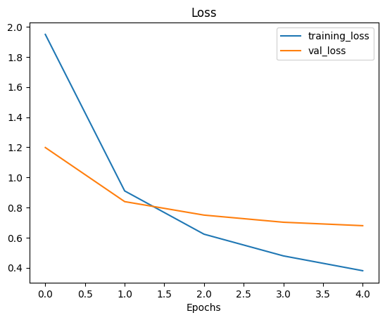

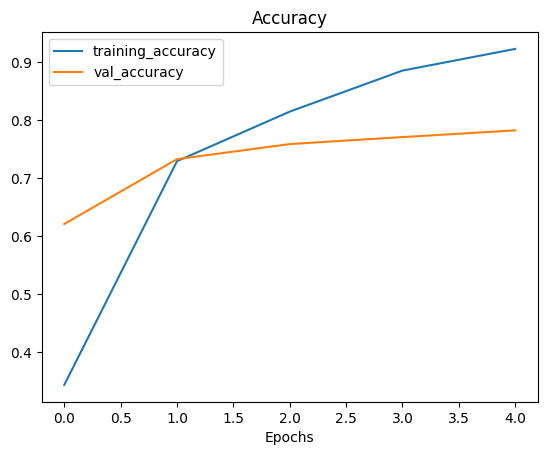

```python
plot_loss_curves(resnet_history)
```

```python
# Resnet summary
resnet_model.summary()
```

```
Model: "sequential_1"
```

```
┏━━━━━━━━━━━━━━━━━━━━━━━━━━━━━━━━━┳━━━━━━━━━━━━━━━━━━━━━━━━┳━━━━━━━━━━━━━━━┓
┃ Layer (type)                    ┃ Output Shape           ┃       Param # ┃
┡━━━━━━━━━━━━━━━━━━━━━━━━━━━━━━━━━╇━━━━━━━━━━━━━━━━━━━━━━━━╇━━━━━━━━━━━━━━━┩
│ lambda (Lambda)                 │ (None, 2048)           │             0 │
├─────────────────────────────────┼────────────────────────┼───────────────┤
│ output_layer (Dense)            │ (None, 10)             │        20,490 │
└─────────────────────────────────┴────────────────────────┴───────────────┘
```

```
 Total params: 61,472 (240.13 KB)
```

```
 Trainable params: 20,490 (80.04 KB)
```

```
 Non-trainable params: 0 (0.00 B)
```

```
 Optimizer params: 40,982 (160.09 KB)
```

We have 20,490 parameters in the output layer to suit our dataset.

Lambda showing 0 parameters, but thruthfully has 23,564,800 parameters. Goes to show how many patterns are prelearned for the model.

Lets do the same for EfficientNetB0 model.

The setup will be the exact same, except `model_url` and `experiment_name`

```python
# Create model
efficientnet_model = create_model(model_url=efficientnet_url, # use EfficientNetB0 TensorFlow Hub URL
                                  num_classes=train_data_10_percent.num_classes)

# Compile EfficientNet model
efficientnet_model.compile(loss='categorical_crossentropy',
                           optimizer=tf.keras.optimizers.Adam(),
                           metrics=['accuracy'])

# Fit EfficientNet model
efficientnet_history = efficientnet_model.fit(train_data_10_percent, # only use 10% of training data
                                              epochs=5, # train for 5 epochs
                                              steps_per_epoch=len(train_data_10_percent),
                                              validation_data=test_data,
                                              validation_steps=len(test_data),
                                              callbacks=[create_tensorboard_callback(dir_name="tensorflow_hub",
                                                                                     # Track logs under different experiment name

                                                                                     experiment_name="efficientnetB0")])
```

```
Saving TensorBoard log files to: tensorflow_hub/efficientnetB0/20250829-225402
24/24 ━━━━━━━━━━━━━━━━━━━━ 39s 1s/step - accuracy: 0.4987 - loss: 1.7487 - val_accuracy: 0.7592 - val_loss: 1.2229
24/24 ━━━━━━━━━━━━━━━━━━━━ 30s 1s/step - accuracy: 0.7840 - loss: 1.0277 - val_accuracy: 0.8276 - val_loss: 0.8305
24/24 ━━━━━━━━━━━━━━━━━━━━ 31s 1s/step - accuracy: 0.8347 - loss: 0.7442 - val_accuracy: 0.8464 - val_loss: 0.6749
24/24 ━━━━━━━━━━━━━━━━━━━━ 30s 1s/step - accuracy: 0.8680 - loss: 0.6015 - val_accuracy: 0.8532 - val_loss: 0.5956
24/24 ━━━━━━━━━━━━━━━━━━━━ 31s 1s/step - accuracy: 0.8933 - loss: 0.5081 - val_accuracy: 0.8624 - val_loss: 0.5422
```

This model does better than the other one, with almost 90% accuracy on training, and >85% on validation.

Let's check out the loss curves

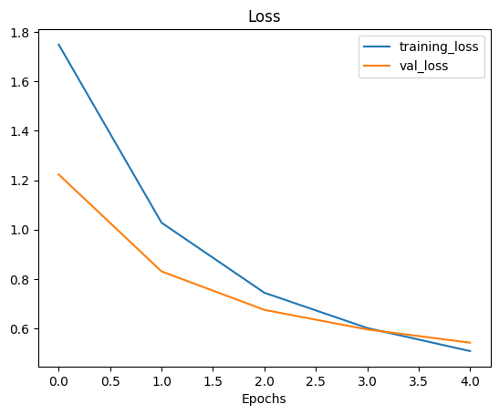

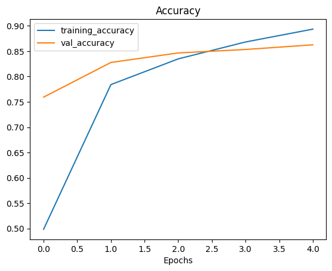

```python
plot_loss_curves(efficientnet_history)
```

```python
efficientnet_model.summary()
```

```
Model: "sequential_2"
```

```
┏━━━━━━━━━━━━━━━━━━━━━━━━━━━━━━━━━┳━━━━━━━━━━━━━━━━━━━━━━━━┳━━━━━━━━━━━━━━━┓
┃ Layer (type)                    ┃ Output Shape           ┃       Param # ┃
┡━━━━━━━━━━━━━━━━━━━━━━━━━━━━━━━━━╇━━━━━━━━━━━━━━━━━━━━━━━━╇━━━━━━━━━━━━━━━┩
│ lambda_1 (Lambda)               │ (None, 1280)           │             0 │
├─────────────────────────────────┼────────────────────────┼───────────────┤
│ output_layer (Dense)            │ (None, 10)             │        12,810 │
└─────────────────────────────────┴────────────────────────┴───────────────┘
```

```
 Total params: 38,432 (150.13 KB)
```

```
 Trainable params: 12,810 (50.04 KB)
```

```
 Non-trainable params: 0 (0.00 B)
```

```
 Optimizer params: 25,622 (100.09 KB)
```

The model actually has 4,049,564 parameters. Much less than ResNet50V2, yet yields better performance.

### Comparing models using TensorBoard

We've visually compared the performance of the two models via the accuracy and loss scores/graphs. But what happens if you have more than 2 models?

The environment `TensorBoard` comes in handy for this visualization.

Since we used tensorboard callbacks, all training logs are saved and can be uploaded into [TensorBoard.dev](https://tensorboard.dev/)

Once you upload the modelling experiments onto `TensorBoard.dev`, you can share it to others, accompanying the notebook.

### Uploading experiments to TensorBoard

To upload the TensorFlow logs onto TensorBoard, you can use the command:

```
code
Upload TensorBoard dev records

!tensorboard dev upload --logdir ./tensorflow_hub/ \
  --name "EfficientNetB0 vs. ResNet50V2" \
  --description "Comparing two different TF Hub feature extraction models architectures using 10% of training images" \
  --one_shot
```

Where:

- `--logdir` is the target upload directory
- `--name` is the name of the experiment
- `--description` is a breif description of the experiment
- `--one_shot` exits the TensorBoard uploader once uploading is finished

Running `tensorboard dev upload` command will ask you to authorize upload to TensorBoard.dev. After you authorized the upload, log files will then be uploaded.

```python
# upload tensorboard dev records
!tensorboard dev upload --logdir ./tensorflow_hub/ \
--name 'EfficientNetB0 vs. ResNet50V2' \
--description 'Comparing two different TensorFlow Hub feature extration model architectures using 10% of training data' \
--one_shot
```

```
2025-08-31 22:40:24.863022: I tensorflow/core/util/port.cc:153] oneDNN custom operations are on. You may see slightly different numerical results due to floating-point round-off errors from different computation orders. To turn them off, set the environment variable `TF_ENABLE_ONEDNN_OPTS=0`.
2025-08-31 22:40:31.291947: I tensorflow/core/util/port.cc:153] oneDNN custom operations are on. You may see slightly different numerical results due to floating-point round-off errors from different computation orders. To turn them off, set the environment variable `TF_ENABLE_ONEDNN_OPTS=0`.
======================================================================
ERROR: The `tensorboard dev` command is no longer available.

TensorBoard.dev has been shut down. For further information,
see the FAQ at <https://tensorboard.dev/>.
======================================================================
```